# Capstone_MaelvDijk_DMaE_Addendum

Maël

2022-04-14

## Addendum

In deze bijlagen worden nog een paar analyses gedeeld die geen onderdeel meer uitmaken van de hoofdtekst. De overwegingen hiervoor zijn ruimte gebrek, data gebrek en een lage statische betrouwbaarheid. Toch worden de code, grafieken en analyses hieronder nog meegenomen ter referentie en om de mogelijkheid te bieden om deze later toe te passen. De grafieken zijn verder niet voorzien van opmaak in tegenstelling tot de grafieken in de hoofdtekst gezien deze dienen voor exploratie doeleinden en zijn niet bedoelt voor presentaties o.i.d.

Analyse D001

D001 is weinig behandelt in de hoofdtekst omdat de focus van dit onderzoek de Nederlandse banenmarkt heeft. Toch bevat D001 interessante inzichten. Hoewel de vertaling naar de Nederlandse markt niet makkelijk te maken is. Zo is loon nagenoeg niet vergelijkbaar (bijv. door afwezigheid van medische voorzieningen in het Amerikaanse salaris). Toch kan kunnen overkoepelende inzichten verhelderend werken

Neem de eerste van onderstaande drie grafieken. Hierin kan uit de verdeling worden afgeleid dat een data analist een doorgaans lichter profiel (minder skills) nodig heeft dan een data engineer of data scientist. Wanneer vervolgens de tweede grafiek beoordeeld wordt komt er nog iets interessants naar boven. Het feit dat data scientisten meer verdienen dan data engineers. Gezien het grote gat tussen de vraag naar data engineers en data scientisten in deze set is dit misschien niet geheel onverwacht. Maar, een hypothese bij aanvang van dit onderzoek was dat data engineers het hoogste salaris zouden genieten van deze drie rollen.

een laatste interessante ontdekking is dat het aantal gevraagde skills nauwelijks toeneemt naarmate het aangeboden salaris stijgt. De curve in de derde grafiek verschuift nagenoeg niet naar rechts naarmaten er in hogere salaris groepen wordt gekeken. Hier zou een aannamen zijn dat werknemers in het data veld worden beloond op basis van diepgaande kennis en specialisatie in plaats van een breed en oppervlakkig kennis gebied. Het kantel punt lijkt hier te liggen op ongeveer zeven á acht skills.

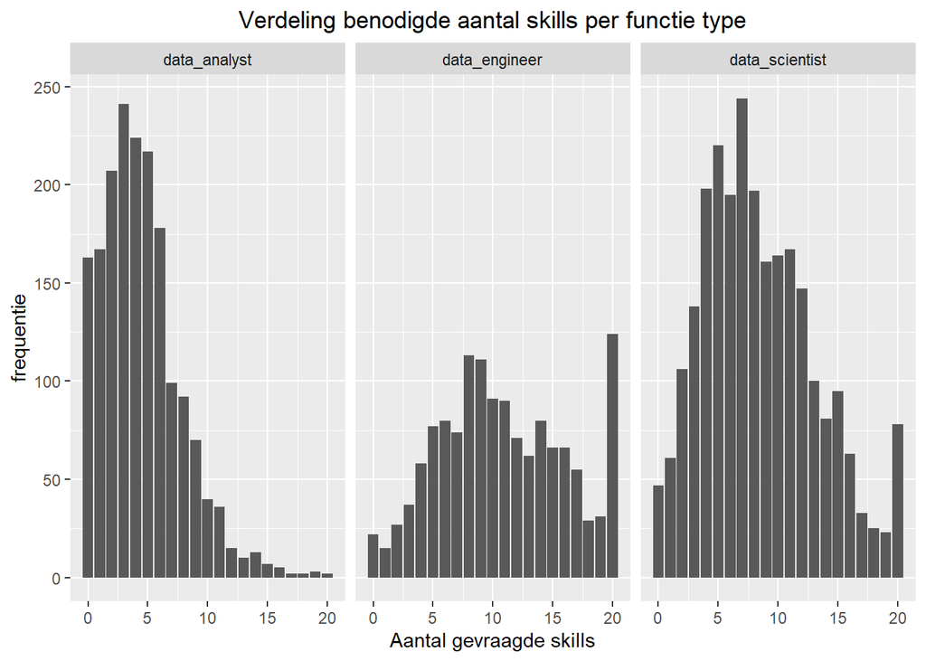

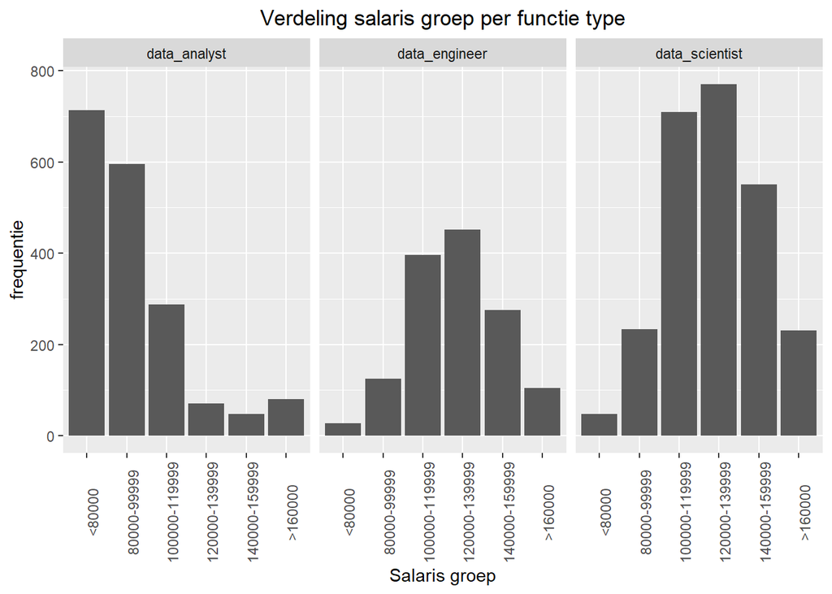

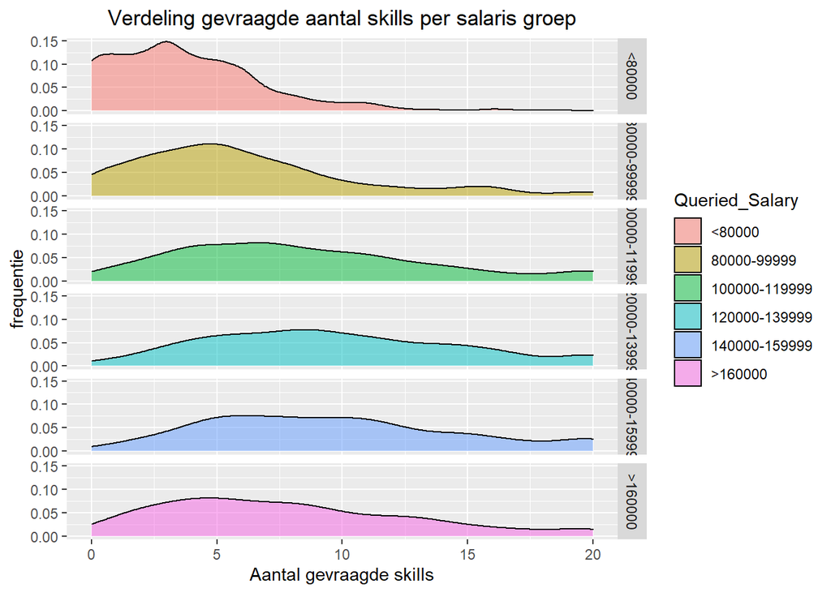

### Ontwikkeling functie type opdrachtgevers

Ondanks dat het niet mogelijk is om nu nog een uitspraak te doen over de ontwikkeling van vraag bij opdrachtgevers wordt er wel vast een artefact aangeleverd in de vorm van een tijdserie op basis van functietype. Deze grafiek en de bijbehorende code zijn hieronder terug te vinden voor toekomstig gebruik. Omdat er te weinig data is om een goede tijdsreeks analyse te maken zal de grafiek verder niet van commentaar worden voorzien.

Er is hier wel overwogen een tweede artefact mee te leveren, namelijk een stuk code om het verloop van de vraag door individuele opdracht gevers weer te geven. Echter zegt de grafiek door de geringe hoeveelheid data te weinig. Om verkeerde interpetaties van de data te voorkomen wordt deze code dan ook niet meegeleverd. Zodra er genoeg data verzamelt is kan aan de hand van deze file een nieuw onderdeel worden toegevoegd om deze verandering over de tijd weer te geven.

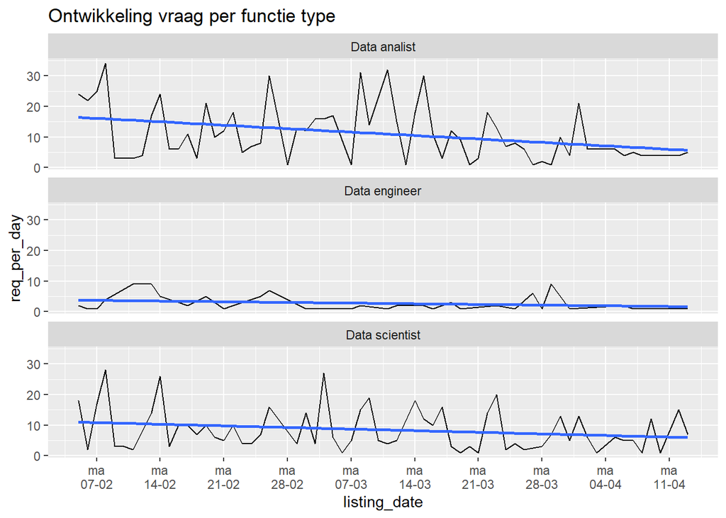

```r
df_indeed_final_date_filtered %>%
  group_by(
    listing_date,
    job_type) %>%
  summarise(
    req_per_day= n(),
    .groups= "keep") %>%
  ggplot(
    aes(
      x= listing_date,
      y= req_per_day
      )) +
  geom_line() +
  facet_wrap(
    vars(job_type),
    ncol=1) +
  stat_smooth(
    method = "lm",
    se= FALSE
    ) +
  scale_x_date(
    date_labels = "%a\n%d-%m",
    date_breaks = "week"
               ) +
  labs(
    title= "Ontwikkeling vraag per functie type"
  )
```

### Ontwikkeling vraag naar data professionals

Voor de deelvraag “In hoeverre sluit het”curriculum” van HoB zich aan bij de ontwikkelende markt?” was het naast de huidige situatie ook de bedoeling een trend analyse te doen. Helaas is duidelijk geworden dat er te weinig data beschikbaar is om een betrouwbare analyse hierop te doen. Hoewel dit tijdens het onderzoek is gebleken zijn de artefacten hieronder aangeboden voor analyses op een later moment. Zo kan er bijvoorbeeld achterhaald worden of er bepaalde momenten in het jaar zijn waar er meer wordt gezocht naar data professionals.

In de eerste grafiek hieronder is een negatieve trend te zien wanneer er gekeken wordt naar de totale instroom aan “data” vacatures. De tweede grafiek toont een autocorrelatie. Op de x-as zijn de dagen vanaf het huidige datapunt gemeten (0 is dezelfde dag). Op de y-as is de mate van correlatie. Alle punten boven of onder de blauwe lijnen zouden statisch significant moeten zijn. Op het moment van schrijven lijkt er een significant patroon op te treden iedere 6 dagen. Echter is de correlatie slechts 0.3 wat aanduidt dat het patroon erg zwak is.

#### Instroom vanaf 5 februari 2022

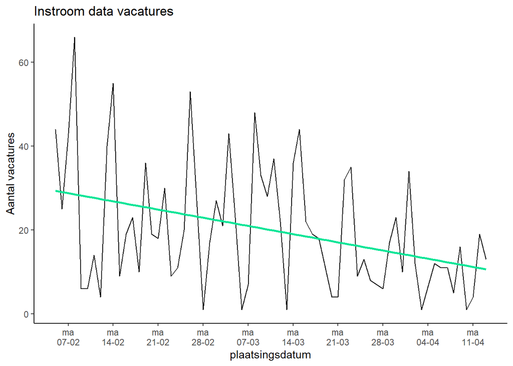

```r
# filter data to contain only points after 5th of february
plot_indeed_timeseries_data(df_indeed_final_date_filtered)
```

#### Auto-correlatie instroom

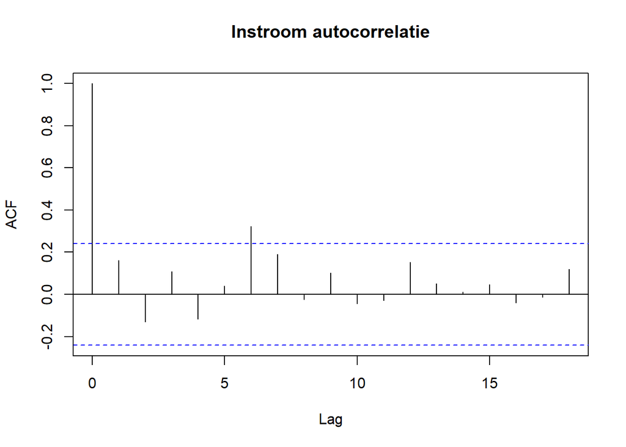

```r
#create listing date table
listing_date_table <- table(df_indeed_final_date_filtered$listing_date)

#calculate autocorrelation
acf(listing_date_table, main= "Instroom autocorrelatie")
```

Zoals gesteld kan er met de huidige data weinig betekenis worden gehaald uit de trendanalyse. Wel biedt de code mogelijkheid voor latere toepassing. Zo kan er na een langere termijn van scraping een analyse worden gedaan per opdracht gever of functietype. Ook kan er gekeken worden naar de algehele markt ontwikkeling en de beste momenten om opdrachtgevers te benaderen. Dit zouden dan ook aanbevelingen zijn voor een vervolgonderzoek of toepassing van de bovenstaande grafieken en bijbehorende code.